# Features affecting the bike duration

## Investigation Overview

In this investigation, I wanted to look at the characteristics of rides that could be used to increase the profit of the company. The main focus was on the duration of the ride, distance travelled, day of the ride, hour of the ride, age, user type.

## Dataset Overview

The data consisted of bike duration and attributes of approximately 183412 rides.

- This data set includes information about individual rides made in a bike-sharing system covering the greater San Francisco Bay area during 2019.
- Bay Wheels is the Bay Area’s regional bicycle share system that operates in the cities of Berkeley, Emeryville, Oakland, San Jose and the city and county of San Francisco.
- Bay Wheels allows users to make point-to-point trips using shared bicycles.

## Data Cleaning

1. Drop the Null values
2. Drop the "Other" in member gender
3. Create a column for the rider age
4. Drop the rider older than 80
5. Create a columns for the day and hour of the ride
6. Create a column for different return station
7. Create a column for the distance traveled
8. Convert the end and start station id to int
9. Remove Outliers using IQR Score

## Distribution of start and end hour bike riding

The distribution of the starting hour and ending hour are similar. The peak in the morning is at 8:00AM and 9:00AM and the peak in the evening is at 5:00PM and 6:00PM. It appears that the peak is during going to work from home and return back from work to home. The company of bike can create some promotion during the lunch break to encourage the users to go to restaurent.

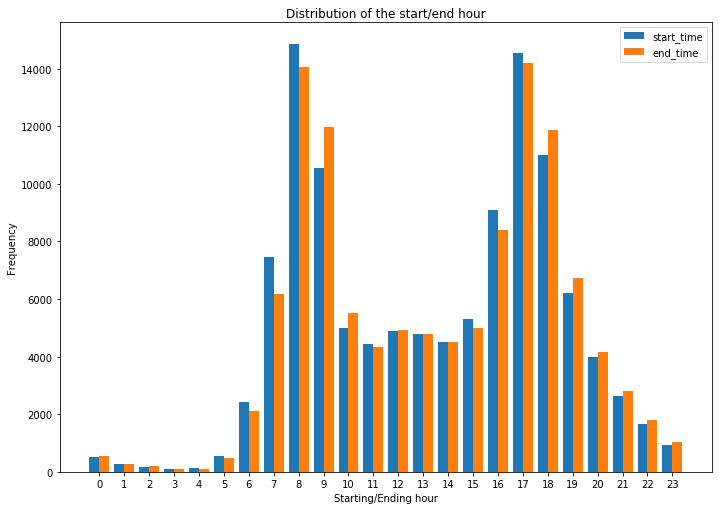

```python
plt.figure(figsize = (11.69, 8.27))
plt.bar(bike["start_time"].dt.hour.value_counts().index,
        height = bike["start_time"].dt.hour.value_counts(),
        align = "edge",
        width = -0.4,
        label = "start_time")
plt.bar(bike["end_time"].dt.hour.value_counts().index,
        height = bike["end_time"].dt.hour.value_counts(),
        align = "edge",
        width = 0.4,
        label = "end_time")

ticks = range(0,24)
labels = ['{}'.format(v) for v in ticks]
plt.xticks(ticks, labels);

plt.xlabel("Starting/Ending hour")
plt.ylabel("Frequency")
plt.title("Distribution of the start/end hour")
plt.legend();
```

## Distribution of member age

The distribution of the rider age is normal distibution but right skewed. The number of Males riders are much more than Females and the average age for rideres is around 33 years. The company can create more promotrion for women to ecourage them and for people more than 40 years.

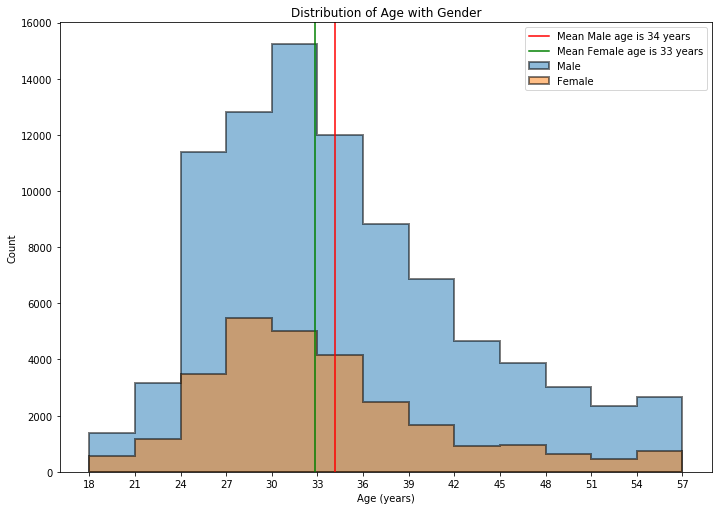

```python
plt.figure(figsize = (11.69, 8.27))
step = 3
bins = np.arange(bike.age.min(), bike.age.max()+step, step)
kwargs = dict(histtype='stepfilled', alpha=0.5, edgecolor="black", linewidth=2)

plt.hist(data=bike[bike.member_gender == "Male"], x="age",
         bins= bins, label = "Male", **kwargs);
plt.hist(data=bike[bike.member_gender == "Female"], x="age",
         bins= bins, label = "Female", **kwargs);
#sb.displot(data=bike, x="age", bins= bins, hue = "member_gender", kde=True);
plt.axvline(x=bike.groupby("member_gender").age.mean().Male,
            label = "Mean Male age is {:0.0f} years".format(bike.groupby("member_gender").age.mean().Male),
            color = "red")
plt.axvline(x=bike.groupby("member_gender").age.mean().Female,
            label = "Mean Female age is {:0.0f} years".format(bike.groupby("member_gender").age.mean().Female),
            color = "green")
plt.legend(loc = 'upper right');
plt.xlabel("Age (years)");
plt.ylabel("Count");
plt.title("Distribution of Age with Gender")
plt.xticks(bins, bins);
```

## Relation between user type and the duration

Average duration of "Customer" is heigher than "Subscriber" and both are around 10min. We need to create promotion for "Customer" to be "Subscriber".

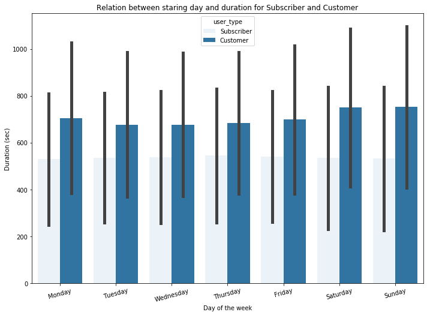

```python
plt.figure(figsize = (11.69, 8.27))
base_color = sb.color_palette()[0]
sb.barplot(data=bike, x='start_day', y='duration_sec', hue="user_type",
           color=base_color,
           errwidth=5,
           ci='sd')
plt.xticks(rotation=15);
plt.xlabel("Day of the week");
plt.ylabel("Duration (sec)");
plt.title("Relation between staring day and duration for Subscriber and Customer");
```

## The Distribution of user type and weekday

During the weekends the use of bike drop to less than half of working day. We need to create promotion to ecourage people them to ride during weekends.

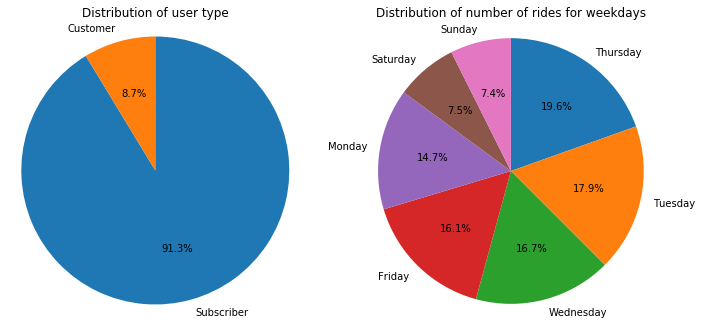

```python
plt.figure(figsize = (11.69, 8.27))
###############################################################################
plt.subplot(1,2,1)
plt.pie(bike.user_type.value_counts(),
        labels = bike.user_type.value_counts().index ,
        startangle = 90,
        counterclock = False,
        autopct='%1.1f%%');
plt.axis('square');
plt.title("Distribution of user type");
###############################################################################
plt.subplot(1,2,2)
plt.pie(bike.start_day.value_counts(),
        labels = bike.start_day.value_counts().index ,
        startangle = 90,
        counterclock = False,
        autopct='%1.1f%%');
plt.axis('square');
plt.title("Distribution of number of rides for weekdays");
```